# CS_mTurk_dataCleaning

Bernice Cheung

8/20/2020

# Load and prep data

Raw data was directly downloaded from Qualtric on 8/20/20. A filter that only includes participants who met the inclusion criteria, consented and completed the survey was applied prior to downloading it. 253 participants are included in this raw dataset.

```r
# load raw data
rawDf <- read.csv("./rawData/Goal Representation-mTurk-CrossSection_August 20, 2020_23.53.csv",stringsAsFactors = F)
```

Organize the raw dataframe

```r
# delete the first two rows of labels and questions
rawDf_cleaned <- rawDf[-c(1,2),]

# write the data without the 2 rows
write.csv(rawDf_cleaned,"./inputs/raw_clean.csv",row.names = F)

# reload the raw cleaned dataframe
rawDf_cleaned <- read.csv("./inputs/raw_clean.csv",stringsAsFactors = F)
```

Transform and generate variables

```r
# convert the duration in seconds to minutes
rawDf_cleaned$Duration <- rawDf_cleaned$Duration..in.seconds./60

# transfer "none" to NAs for subject 58881
list_df <- rawDf_cleaned %>% dplyr::select(contains("goal_list"))

subjectIdx <- which(rawDf_cleaned$MTurkCode == 58881)
list_df[75,c(3,4,5)] <-""

# Generate the number of goals subject listed
rawDf_cleaned$listNum <- rowSums(list_df != "")

# Generate the duration per goal
rawDf_cleaned$timePerGoal <- rawDf_cleaned$Duration/rawDf_cleaned$listNum

# export all listed goals for data screening
list_df$MTurkCode <- rawDf_cleaned$MTurkCode
write.csv(list_df, "./outputs/listedGoals.csv", row.names = F)
```

Transform the data relevant to goal rating into a long format dataframe

```r
# subset goal rating related dataset
goalRating <- subset(rawDf_cleaned, select = G1_1:G39_5)
goalRating <- bind_cols(goalRating, rawDf_cleaned[,c("MTurkCode","listNum", "total_goal")])

# transform the dataset to long format
goalRating_long <- goalRating %>% gather(variable, rating, G1_1:G39_5)

# transform existing question number to the corresponding variable name and goal number

goalRating_long$goal <- str_sub(goalRating_long$variable,-1,-1)

variableName <- c("construal_level", "temporal_duration", "frequency", "specificity", "end_state_specificity", "approach_avoidance", "attainment_maintenance", "measurability", "importance", "meaningfulness", "instrumentality", "connectedness", "attractiveness_achievement", "attractiveness_progress", "social_desirability", "difficulty", "affordance", "attainability", "clarity", "control", "external_motivation", "introjected_motivation", "identified_motivation", "intrinsic_motivation", "ought_motivation", "ideal_motivation", "basic_needs", "commonality", "visibility", "external_importance", "conflict")
progressName <- c("commitment", "urgency", "effort", "advancement", "initial_time", "regret", "procrastination", "failure")
nameList <- c(variableName, progressName)
questionNum <- paste0("G", 1:39, "_")

nameDf <- data.frame("question_number" = questionNum,
                     "variable_name" = nameList)

for (idx in 1: nrow(nameDf)){
  goalRating_long$variable[grepl(nameDf$question_number[idx],goalRating_long$variable)] <- as.character(nameDf$variable_name[idx])
}

# get rid off the NAs for questions corresponding to goals that the subjects didn't list
goalRating_long <- goalRating_long[goalRating_long$goal <= goalRating_long$listNum,]
```

# Exclude participants

### Exclusion Criteria 1: bots response & repetitive response

All listed goals were viewed by Bernice and responses from bots and repetitive responses were identified.

```r
id_bots <- c(11385, 34736,75119,69558,48831,63082,99680,53772,26999,87954,14942,37853,43774,21971,74791,34681,13891,99529,48560,60936,37448,60650,48295)
```

23 subjects were screened out. Screening results are showed on ./outputs/listedGoals.csv (grey indicates bots responses, orange indicates repetitive responses)

Below is a list of subject whom I’m not sure if should be excluded based on their answers

```r
id_question <- c(30999, 72969, 76327, 63567)
```

### Exclusion Criteria 2:Task Duration

Descriptive and histogram on timePerGoal (task duration / number of listed goals) for all participants

```r
# Descriptive on duration
describe(rawDf_cleaned$timePerGoal)
```

```
##    vars   n mean   sd median trimmed  mad  min   max range skew kurtosis   se
## X1    1 253 9.65 4.97   8.59       9 3.61 2.65 36.75  34.1 1.77     4.83 0.31
```

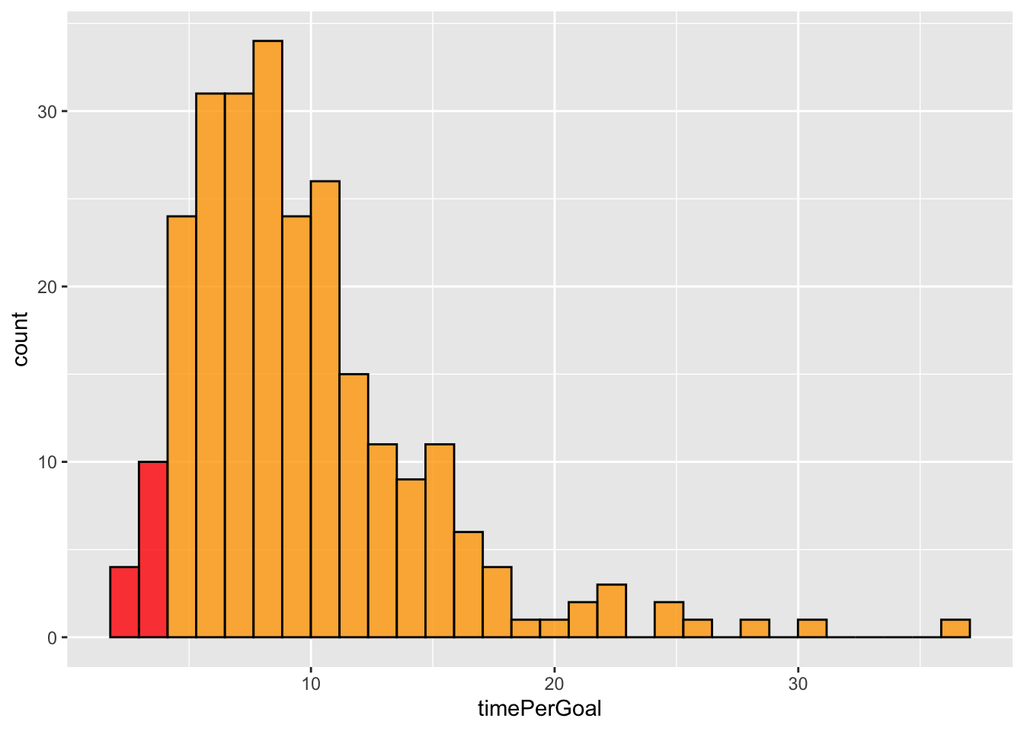

```r
# Histogram
colors <- c(rep("red",2), rep("orange",28))
rawDf_cleaned %>% ggplot(aes(timePerGoal)) + geom_histogram(fill   = colors,
                   colour = "black",
                   alpha  = .8)
```

The exclusion criteria for the SONA study was less than 5min per goal. Based on this histogram, I use 4 min per goal as the threshold. 11 subject met this exclusion criteria

```r
id_durationShort <- rawDf_cleaned[rawDf_cleaned$timePerGoal <4,c("MTurkCode", "Duration","timePerGoal", "listNum")]
```

### Exclusion Criteria 3: Attention check questions

The SONA version has 3 attention check questions. But because we didn’t include the individual difference measures in the present one, it only has one attention check question.

```r
id_check <- rawDf_cleaned[rawDf_cleaned$check1 !=17, c("MTurkCode", "Duration","timePerGoal", "listNum")]
```

8 subject failed at the attention check question

### Exclusion Criteria 4: Repetitive responses

```r
# extract columns with likert scale ratings
ratingDf <- dplyr::select(rawDf_cleaned, "G1_1":"P45_4_3")

# extract the max number of repetitive response in a row
variation <- apply(ratingDf,1,function(x) rle(x))
variation.length <-unlist(lapply(variation,function(x) max(x$lengths)))
describe(variation.length)
```

```
##    vars   n mean   sd median trimmed  mad min max range skew kurtosis   se
## X1    1 253 5.23 2.57      4    4.78 1.48   2  16    14 2.06     5.16 0.16
```

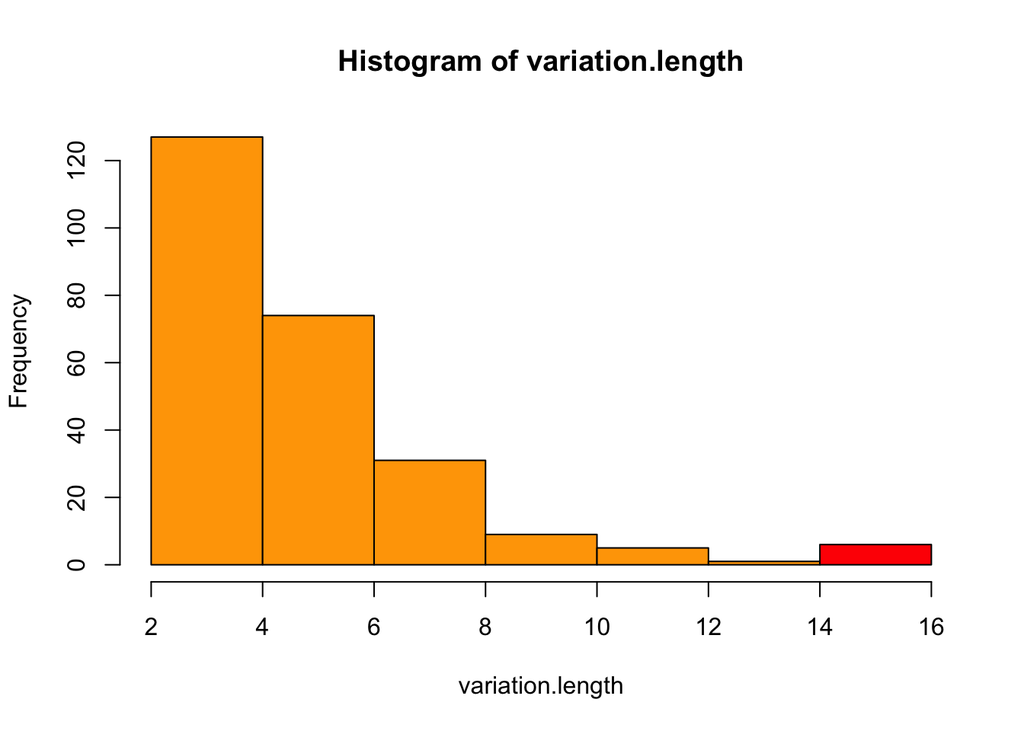

```r
hist(variation.length, col = c(rep("orange", 6), rep("red", 1)))
```

```r
rawDf_cleaned$invariance_max <- variation.length
```

The histogram doesn’t show a clear cut off line. For the SONA study, our threshold is 20. No subject is excluded based on this criteria.

### Exclusion Criteria 5: Missing data in the goal rating session

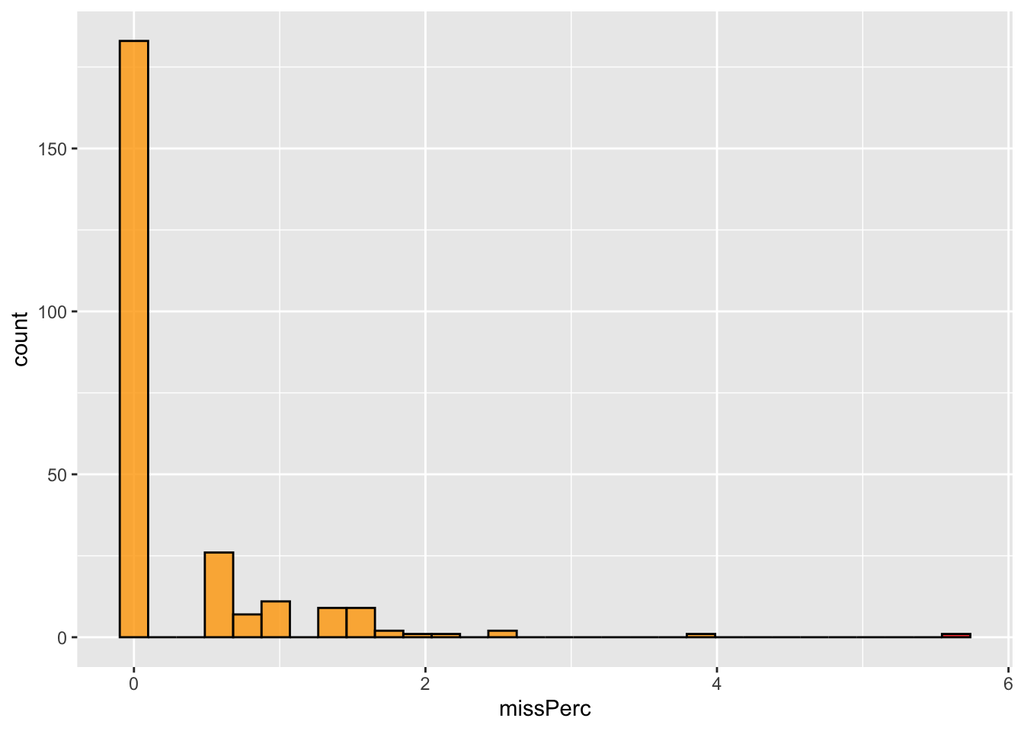

```r
# calculate the percentage of missing data
missDf <- goalRating_long %>%
  group_by(MTurkCode) %>%
  summarise(missNum = sum(is.na(rating)),
            totalNum = mean(listNum) * 39,
            missPerc = ((missNum/totalNum) * 100))

# record the missing proportion
rawDf_cleaned$missPerc <- missDf$missPerc

# visualize the percentage of missing data
color <- c(rep("orange", 29), "red")
missDf %>% ggplot(aes(missPerc)) +
  geom_histogram(fill= color,
                   colour = "black",
                   alpha  = .8)
```

The maximum percentage of missing is below 6%. No subject is excluded based on this critiria.

### Organize subjects who are excluded

Exclude subjects if they were identified based on any of the exclusion Criteria. Based on all 5 exclusion criteria, 34 participants should be excluded.

```r
# aggregate id and relevant info.
id_candidate <- unique(c(id_bots, id_durationShort$MTurkCode, id_check$MTurkCode))
candidateDf <- rawDf_cleaned %>% dplyr::select(c("MTurkCode", "Duration", "timePerGoal","listNum", "check1", "invariance_max", "missPerc")) %>% filter(MTurkCode %in% id_candidate)
```

Below is the relevant info for those who are subject to exclusions only based on attention check question.

```r
# subjects that are excluded based on other criteria
id_candidate2 <- unique(c(id_bots, id_durationShort$MTurkCode))

# check relevant info. for those who are subject to exclusion only based on attention check qeustion
candidateDf %>%
  filter(!MTurkCode %in% id_candidate2) %>%
  kable(format = "html", escape = F) %>%
  kable_styling(bootstrap_options = c("striped", "hover", "condensed"), full_width = F,position = "center",fixed_thead = T)
```

| MTurkCode | Duration | timePerGoal | listNum | check1 | invariance_max | missPerc |
| --- | --- | --- | --- | --- | --- | --- |
| 44597 | 25.51667 | 5.103333 | 5 | 1,3,5,10,14 | 5 | 0 |
| 99516 | 39.06667 | 7.813333 | 5 | 1,3,9,12,17 | 10 | 0 |
| 70522 | 43.93333 | 8.786667 | 5 |  | 5 | 0 |
| 56198 | 64.68333 | 21.561111 | 3 | 19 | 5 | 0 |
| 51686 | 42.98333 | 8.596667 | 5 | 1,3,9,10,16,17,20 | 7 | 0 |

Based only on the info showed in these table, these 5 subjects seem responsible except failing at the attention check questions. I don’t think it’s reasonable to exclude them at this point.

29 subject will be excluded based on their listed goals being judged as random and task duration

```r
questionDf <- rawDf_cleaned %>% dplyr::select(c("MTurkCode", "Duration", "timePerGoal","listNum", "check1", "invariance_max", "missPerc")) %>% filter(MTurkCode %in% id_question) %>%
  kable(format = "html", escape = F) %>%
  kable_styling(bootstrap_options = c("striped", "hover", "condensed"), full_width = F,position = "center",fixed_thead = T)
```

clean datasets

```r
# exclude subject from both the wide and long format datasets
cleanedDf <- rawDf_cleaned[! rawDf_cleaned$MTurkCode %in% id_candidate2,]
goalRating_long_Clean <- goalRating_long[! goalRating_long$MTurkCode %in% id_candidate2, ]
```

# Data transformation

#### The “I’m not sure” response

“construal_level”,“approach_avoidance” and “attainment_maintenance” question have an option for “I’m not sure” because they ask subjects to categorize their goals. The corresponding numeric value is 8. These values are transformed to 99 in order to be inspected.

```r
goalRating_long_R <- goalRating_long_Clean

# transform the "I'm not sure" response to 99
goalRating_long_R <- goalRating_long_R %>%
  mutate(rating = replace(rating,
                          rating == 8 & variable %in% c("construal_level","approach_avoidance","attainment_maintenance"),
                          99))
```

#### The “not specified” response

temporal_duration, frequency and end_state_specificity question have an option for “not specified” because they ask about features that may not be applicable to all goals. The corresponding numeric value for each question is specified in the script. These values are transformed to 999 in order to be inspected.

```r
# transform the "not specified" response to 999
goalRating_long_R <- goalRating_long_R %>%
  mutate(rating = replace(rating,
                          rating == 5 & variable == "temporal_duration", 999)) %>%
  mutate(rating = replace(rating, rating == 3 & variable == "frequency", 999)) %>%
  mutate(rating = replace(rating, rating == 4 & variable == "end_state_specificity", 999))
```

### Reverse code

Based on the correlation matrix, I decided to reverse code 5 variable: “approach_avoidance”, “initial_time”, “end_state_specificity”, “frequency”, “attainment_maintenance”. The decision is based on their correlations with other variables. Before recording, they are negatively correlated with most of the variable.

```r
goalRating_long_R$rating[goalRating_long_R$variable == "approach_avoidance"] <- recode(goalRating_long_R$rating[goalRating_long_R$variable == "approach_avoidance"], '1' = 7, '2' = 6, '3' = 5, '5' = 3, '6' = 2, '7' = 1)
goalRating_long_R$variable[goalRating_long_R$variable == "approach_avoidance"] <- "approach_avoidance_R"

goalRating_long_R$rating[goalRating_long_R$variable == "initial_time"] <- recode(goalRating_long_R$rating[goalRating_long_R$variable == "initial_time"], '1' = 8, '2' = 7, '3' = 6, '4' = 5 , '5' = 4, '6' = 3, '7' = 2, '8' = 1)
goalRating_long_R$variable[goalRating_long_R$variable == "initial_time"] <- "initial_time_R"

goalRating_long_R$rating[goalRating_long_R$variable == "end_state_specificity"] <- recode(goalRating_long_R$rating[goalRating_long_R$variable == "end_state_specificity"], '1' = 3, '2' = 2, '3' = 1)
goalRating_long_R$variable[goalRating_long_R$variable == "end_state_specificity"] <- "end_state_specificity_R"

goalRating_long_R$rating[goalRating_long_R$variable == "frequency"] <- recode(goalRating_long_R$rating[goalRating_long_R$variable == "frequency"], '1' = 2, '2' = 1)
goalRating_long_R$variable[goalRating_long_R$variable == "frequency"] <- "frequency_R"

goalRating_long_R$rating[goalRating_long_R$variable == "attainment_maintenance"] <- recode(goalRating_long_R$rating[goalRating_long_R$variable == "attainment_maintenance"], '1' = 7, '2' = 6, '3' = 5, '5' = 3, '6' = 2, '7' = 1)
goalRating_long_R$variable[goalRating_long_R$variable == "attainment_maintenance"] <- "attainment_maintenance_R"
```

# Compute individual differences measures

The scale composite scores and subscale composite scores are generated based on the scoring keys. A subject will be remove from analysis for a given scale if this person missed more than 1/3 of the items. The composite score for the scale will be NA for that subject.

### COVID-Stress

Data screening: range is normal, and no subject need to be excluded due to missing data

```r
# extract relevant data
COVID_items <- cleanedDf[,grepl("COVID",names(cleanedDf))]

# check range
range(COVID_items, na.rm = T)
```

```
## [1] 1 5
```

```r
# check the number of missing data per subject
COVID_NA <- rowSums(is.na(COVID_items))

# check if there's any subject miss 1/3 of the items
which(COVID_NA > 1/3 * ncol(COVID_items))
```

```
## named integer(0)
```

Scoring: all items are recoded from 1-5 to 0-4.

```r
# adjust the range
COVID_R <- COVID_items - 1

# compute the means for each sub scale
COVID_scores <- COVID_R %>%
  mutate(danger_mean = rowMeans(dplyr :: select(., COVID.1_1, COVID.1_2,COVID.1_3,COVID.1_4, COVID.1_5, COVID.1_6), na.rm = TRUE),
         ses_mean = rowMeans(dplyr :: select(., COVID.1_7, COVID.1_8,COVID.1_9,COVID.1_10, COVID.1_11, COVID.1_12), na.rm = TRUE),
         xeno_mean = rowMeans(dplyr :: select(., COVID.1_13, COVID.1_14,COVID.1_15,COVID.1_16, COVID.1_17, COVID.1_18), na.rm = TRUE),
         contam_mean = rowMeans(dplyr :: select(., COVID.1_19, COVID.1_20,COVID.1_21,COVID.1_22, COVID.1_23, COVID.1_24), na.rm = TRUE),
         trauma_mean = rowMeans(dplyr :: select(., COVID.2_1, COVID.2_2,COVID.2_3,COVID.2_4, COVID.2_5, COVID.2_6), na.rm = TRUE),
         check_mean = rowMeans(dplyr :: select(., COVID.3_1, COVID.3_2,COVID.3_3,COVID.3_4, COVID.3_5, COVID.3_6), na.rm = TRUE)) %>%
  dplyr :: select(danger_mean, ses_mean, xeno_mean,contam_mean, trauma_mean, check_mean)
```

check reliability for each subscale:

```r
# check reliability
alpha(dplyr::select(COVID_R, COVID.1_1, COVID.1_2,COVID.1_3,COVID.1_4, COVID.1_5, COVID.1_6))$total$std.alpha
```

```
## [1] 0.9126692
```

```r
alpha(dplyr::select(COVID_R, COVID.1_7, COVID.1_8,COVID.1_9,COVID.1_10, COVID.1_11, COVID.1_12))$total$std.alpha
```

```
## [1] 0.954966
```

```r
alpha(dplyr::select(COVID_R, COVID.1_13, COVID.1_14,COVID.1_15,COVID.1_16, COVID.1_17, COVID.1_18))$total$std.alpha
```

```
## [1] 0.9441893
```

```r
alpha(dplyr::select(COVID_R, COVID.1_19, COVID.1_20,COVID.1_21,COVID.1_22, COVID.1_23, COVID.1_24))$total$std.alpha
```

```
## [1] 0.9162324
```

```r
alpha(dplyr::select(COVID_R, COVID.2_1, COVID.2_2,COVID.2_3,COVID.2_4, COVID.2_5, COVID.2_6))$total$std.alpha
```

```
## [1] 0.9579122
```

```r
alpha(dplyr::select(COVID_R, COVID.3_1, COVID.3_2,COVID.3_3,COVID.3_4, COVID.3_5, COVID.3_6))$total$std.alpha
```

```
## [1] 0.9363317
```

### combine individual difference measures with demographic

```r
demoDf <- cleanedDf %>%
  select(MTurkCode,gender : subjectiveSES)

indivDiffDf <- bind_cols(demoDf, COVID_scores)
```

# write cleaned datasets

```r
# cleaned long format dataset for goal ratings
write.csv(goalRating_long_R,"./inputs/goalRating_long_R.csv", row.names = F)

# cleaned individual difference dataset
write.csv(indivDiffDf,"./inputs/indivDiffDf.csv", row.names = F)

# cleaned wide format dataset for goal raing summary
goalDf_wide <- cleanedDf %>%
  select(MTurkCode,listNum,total_goal)
write.csv(goalDf_wide, "./inputs/goalDf_wide.csv", row.names = F)

# compile and randomize all listed goals for RA rating
goal_list <- list_df %>%
  filter(!MTurkCode %in% id_candidate2) %>%
  select(contains("goal_list")) %>%
  gather(goal_order, Goals) %>%
  select(Goals) %>%
  slice(sample(1:n())) %>%
  filter(Goals != "")
write.csv(goal_list, "./outputs/listedGoals.csv", row.names = F)
```